# Question

### Graph 1

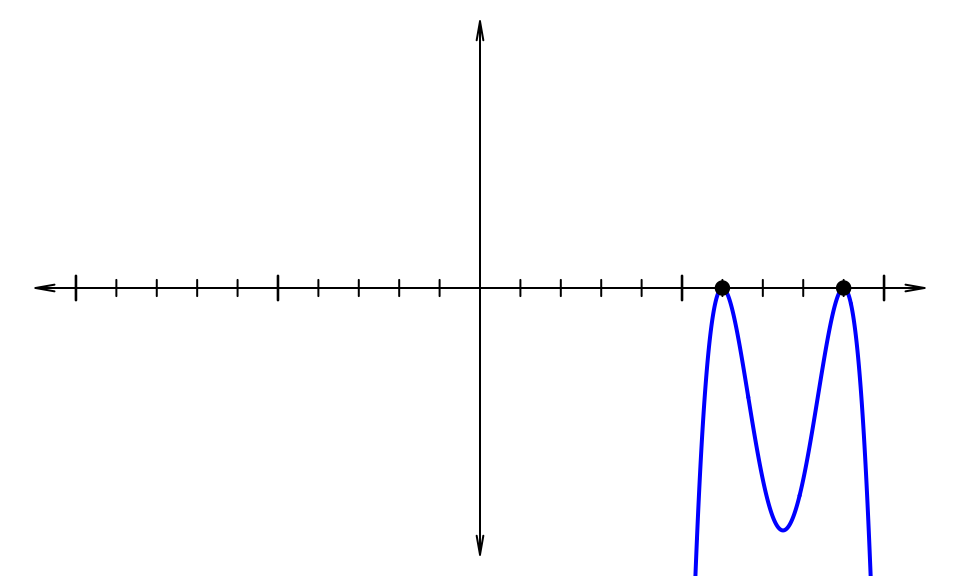

Which function matches Graph 1?

- $A(x)~=~-(x-6)^{2}(x-9)^{2}$
- $B(x)~=~(x-6)(x+9)^{2}$
- $C(x)~=~-(x-6)^{2}(x+9)^{2}$
- $D(x)~=~(x-6)^{2}(x+9)^{2}$
- $E(x)~=~(x+6)(x-9)^{2}$
- $F(x)~=~-(x+6)^{2}(x+9)$

### Graph 2

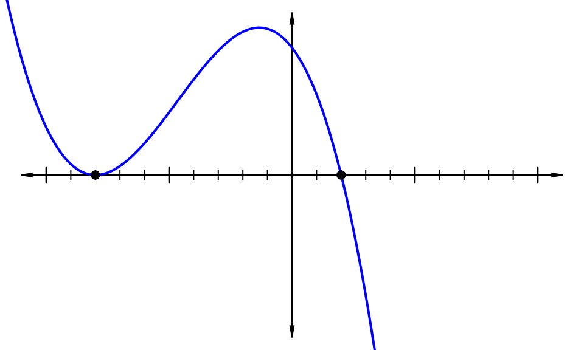

Which function matches Graph 2?

- $A(x)~=~(x-2)(x-8)$
- $B(x)~=~-(x-2)(x+8)$
- $C(x)~=~(x-2)(x+8)$
- $D(x)~=~-(x-2)(x+8)^{2}$
- $E(x)~=~(x+2)^{2}(x-8)$
- $F(x)~=~-(x+2)(x+8)$

### Graph 3

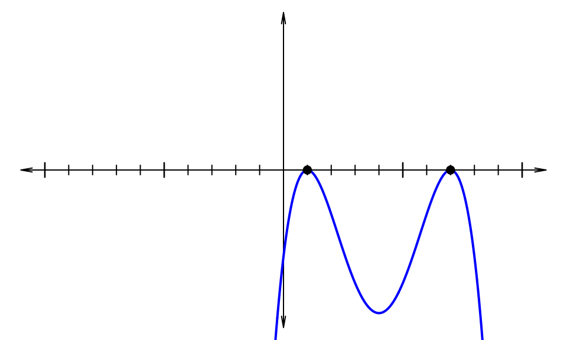

Which function matches Graph 3?

- $A(x)~=~-(x-1)(x-7)^{2}$
- $B(x)~=~-(x-1)^{2}(x-7)^{2}$
- $C(x)~=~(x-1)^{2}(x+7)$
- $D(x)~=~-(x+1)^{2}(x-7)$
- $E(x)~=~(x+1)^{2}(x-7)^{2}$
- $F(x)~=~-(x+1)(x+7)$

### Graph 4

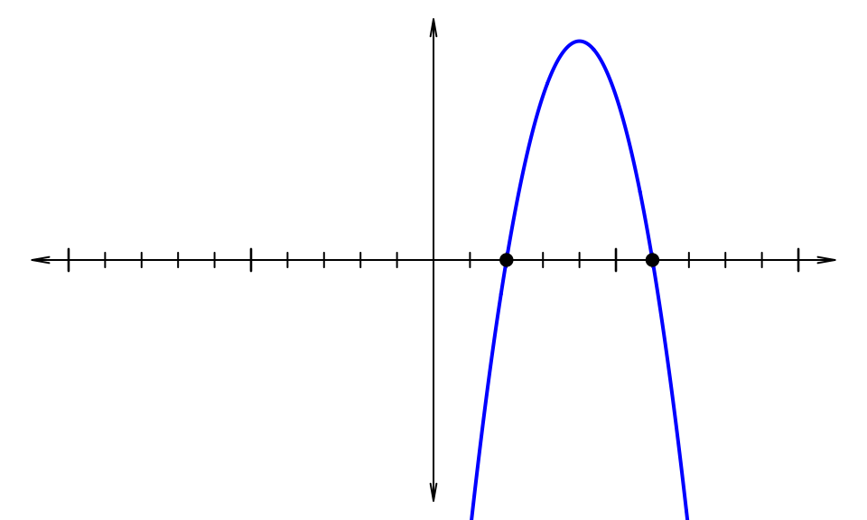

Which function matches Graph 4?

- $A(x)~=~-(x-2)(x-6)$
- $B(x)~=~-(x-2)(x-6)^{2}$
- $C(x)~=~-(x-2)^{2}(x-6)$
- $D(x)~=~(x-2)^{2}(x-6)$
- $E(x)~=~(x-2)(x+6)$
- $F(x)~=~-(x+2)(x-6)^{2}$

## Answerlist

- A(x)
- B(x)
- C(x)
- D(x)
- E(x)
- F(x)
- A(x)
- B(x)
- C(x)
- D(x)
- E(x)
- F(x)
- A(x)
- B(x)
- C(x)
- D(x)
- E(x)
- F(x)
- A(x)
- B(x)
- C(x)
- D(x)
- E(x)
- F(x)

# Solution

- Graph 1 is $A(x)~=~-(x-6)^{2}(x-9)^{2}$
- Graph 2 is $D(x)~=~-(x-2)(x+8)^{2}$
- Graph 3 is $B(x)~=~-(x-1)^{2}(x-7)^{2}$
- Graph 4 is $A(x)~=~-(x-2)(x-6)$

Remember, each factor is $(x-r)$ where $r$ is the root. If the factor is squared, we expect a bounce. Lastly, make sure to pay attention to the sign in front, which will dictate the end behavior.

# Meta-information

extype: cloze exclozetype: schoice|schoice|schoice|schoice exsolution: 100000|000100|010000|100000 exname: match_graph_poly_eq